# 36_assignment2

sumin

2018년 9월 24일

## 1. 분석 주제

### <기부의 동기>

> 우리나라의 연간 기부금액은 11조 원 정도로 비영리조직이 기금을 안정적으로 확보하기에는 무리가 있는 수준이다.  
> 따라서 동정심유발을 통한 일회성의 기부가 아닌 지속적이고 자발적인 개인의 기부의식을 고취시키기 위해 많은 노력이 필요한 실상이다.  
> 필자는 **‘자존감’**이 개인의 심리적 요소로 사회적 행동에 대한 예측, 결과, 매개 변인으로 활용될 수 있다는 한 연구결과를 보고 개인의 기부성향에도 영향을 미치는지 분석해보고자 이 주제를 선정하였다.

[figure not shown]

[figure not shown]

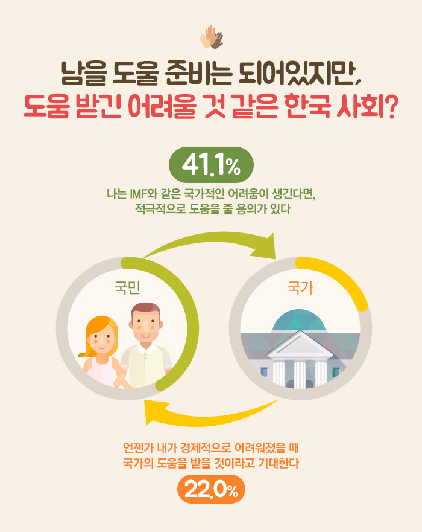

## 2. 데이터

### 1) 출처

[Koweps 한국 복지패널](https://www.koweps.re.kr:442/data/data/list.do)

### 2) 데이터를 선택한 이유

- 표본의 수가 13,647개로 매우 많아 정확한 분석을 할 수 있을 것이라 생각함
- 연간 기부금액에 관한 정보와 개인의 자존감을 분석할 수 있을 만한 질문문항들이 많음
- 근로, 생활 실태 및 만족도, 사회적 환경에 대한 인식 등 여러가지 조사 문항이 있어 다양한 방면으로 조사해볼 수 있을 것

### 3) 분석방향

> 기부의 동기로는 크게  
> 1. 이기적 동기  
> 2. 이타적 동기  
> 가 있다. 이기적 동기는 *세금 감면, 명예 및 체면 등의 보상*에서 기인한 것이고 이타적 동기는 *보상에 대한 기대 없이 타인을 이롭게 하려는 것에서 기인*한 것이다. 필자는 이 중에서도 이타적 동기 중 하나인 자존감과 기부성향의 상관관계에 대해 분석해보고자 한다.  
> 또한 자존감이 높을수록 이타적 동기의 기부가 늘어날수도 있지만 기부를 함에 따라 자존감이 높아질수도 있으므로 이들의 인과관계 역시 분석해보고자 한다.